```r
  dev.copy(png, file="plot2.png", width=1000, height=1000)
```

```r
  dev.off()
```

```r
  #The 5-minute interval that, on average, contains the maximum number of steps
  max_interval <- which.max(meanstep)
```

## Imputing missing values Where data is missing, the mean value of the interval is now used to create a full dataset. The histogram above is now recreated with these updated values - and it can be seen that the mean and median values have fallen.

```r
  #use interval average for missing values
  sum(is.na(df))
```

```
## [1] 2304
```

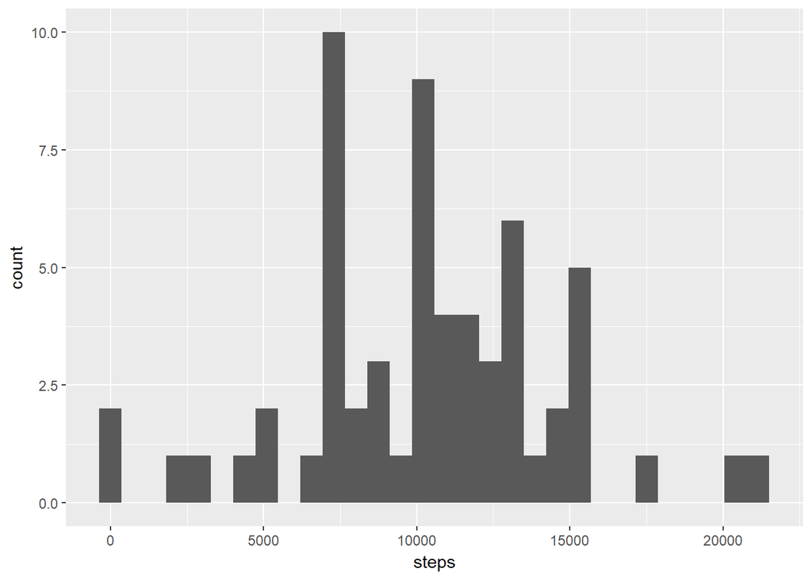

```r
  df2<-df%>%
    mutate(steps=ifelse(is.na(steps)== TRUE,meanstep[interval/5], steps))

  #Histogram of the total number of steps taken each day after missing values are imputed
  totstep2<-aggregate(steps ~ date, data = df2, sum, na.rm = TRUE)
  ggplot(data=totstep2,aes(steps))+geom_histogram()
```

```r
  dev.copy(png, file="plot3.png", width=1000, height=1000)
```

```r
  dev.off()
```

```r
  #Mean and median number of steps taken each day
  mean(totstep2$steps)
```

```
## [1] 10285.23
```

```r
  median(totstep2$steps)
```

```
## [1] 10395
```

```r
  #The mean and median have both fallen when assuming NA values are equal to the average interval value
```

## Are there differences in activity patterns between weekdays and weekends? The data is split into weekdays and weekends, where the averages of each interval are displayed in the graphs below. It can be seen that during the middle of the day, the average number of steps is higher on a weekend than the weekday - this could perhaps be explained by the fact that many of these people sit down while working.

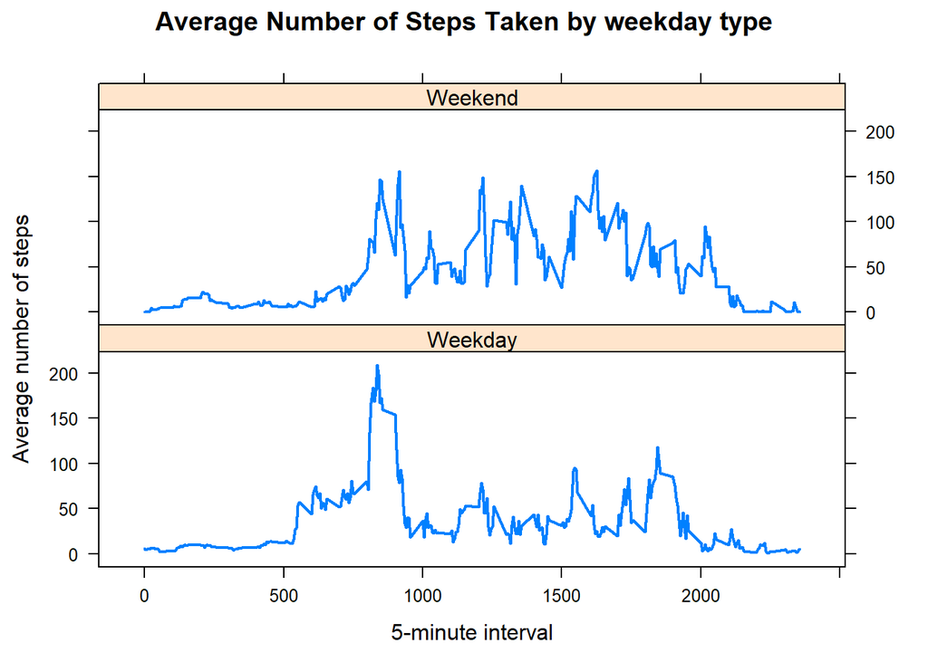

```r
  #Calculate averages given new weekday factor variable
  df2<-df2%>%
    mutate(day = weekdays(date))%>%
    mutate(weekday = ifelse((day== "Saturday") |(day=="Sunday"),"Weekend","Weekday"))

  meanstep2 <- aggregate(steps ~ weekday + interval, data = df2, mean)

  #Panel plot comparing the average number of steps taken per 5-minute interval across weekdays and weekends
  xyplot(steps ~ interval | weekday, data = meanstep2, type = "l", lwd = 2,
         layout = c(1, 2),
         xlab = "5-minute interval",
         ylab = "Average number of steps",
         main = "Average Number of Steps Taken by weekday type")
```

```r
  dev.copy(png, file="plot4.png", width=1000, height=1000)
```

```r
  dev.off()
```